# HW #2 - K-Nearest Neighbors

```r
# 0. Clear environment and load dependencies.
rm(list=ls())
#install.packages("caret")
#install.packages("gmodels")
#install.packages("MLmetrics")
library(caret)
library(class)
library(gmodels)
library(MLmetrics)
```

```r
# 1. Download the dataset Auto.csv.
data = read.csv("Auto.csv", stringsAsFactors = FALSE)
```

```r
# 2. Explore the overall structure of the datasetusing str(). Describe it one paragraph.
str(data)
```

```
'data.frame':   397 obs. of  9 variables:
 $ mpg         : num  18 15 18 16 17 15 14 14 14 15 ...
 $ cylinders   : int  8 8 8 8 8 8 8 8 8 8 ...
 $ displacement: num  307 350 318 304 302 429 454 440 455 390 ...
 $ horsepower  : chr  "130" "165" "150" "150" ...
 $ weight      : int  3504 3693 3436 3433 3449 4341 4354 4312 4425 3850 ...
 $ acceleration: num  12 11.5 11 12 10.5 10 9 8.5 10 8.5 ...
 $ year        : int  70 70 70 70 70 70 70 70 70 70 ...
 $ origin      : int  1 1 1 1 1 1 1 1 1 1 ...
 $ name        : chr  "chevrolet chevelle malibu" "buick skylark 320" "plymouth satellite" "amc rebel sst" ...
```

This dataset consists of 397 observations of 9 variables. The variables mpg, displacement, and acceleration are numeric (decimal/double). The variables cylinders, weight, year, and origin are integers. The variables horsepower and name are character objects (string). Horsepower and year are noteable variables. Horsepower is stored as character despite being best stored as integer data. Year appears to store the last two digits of the full year (i.e., 19XX).

```r
# 3. Convert the attribute horsepower from character to integer.
data$horsepower <- as.integer(data$horsepower)
```

```
NAs introduced by coercion
```

```r
# 4. The horsepower attribute has some missing values. Remove the observations with missing values, i.e., delete the rows with missing values from the data frame.
data <- data[!is.na(data$horsepower),]
```

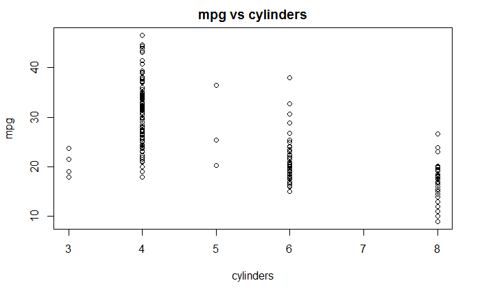

```r
# 5. Explore the data in order to investigate the association between mpg and the other features. Which of the other features seem most likely to be useful in predicting mpg (scatterplots may be useful tools to answer this question). Describe your findings.
plot(data$cylinders, data$mpg, main = "mpg vs cylinders", xlab = "cylinders", ylab = "mpg")
```

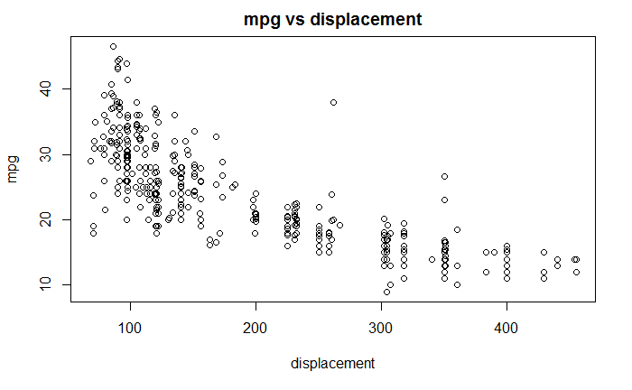

```r
plot(data$displacement, data$mpg, main = "mpg vs displacement", xlab = "displacement", ylab = "mpg")
```

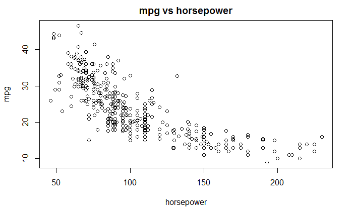

```r
plot(data$horsepower, data$mpg, main = "mpg vs horsepower", xlab = "horsepower", ylab = "mpg")
```

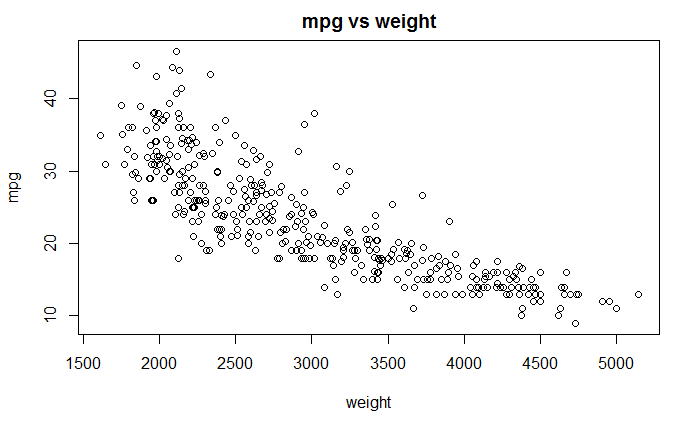

```r
plot(data$weight, data$mpg, main = "mpg vs weight", xlab = "weight", ylab = "mpg")
```

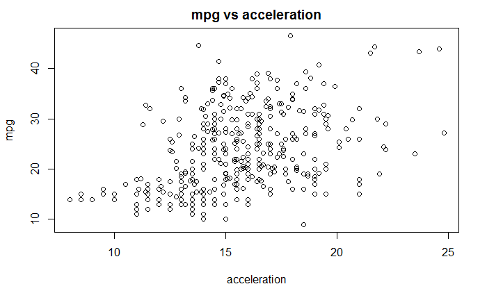

```r
plot(data$acceleration, data$mpg, main = "mpg vs acceleration", xlab = "acceleration", ylab = "mpg")
```

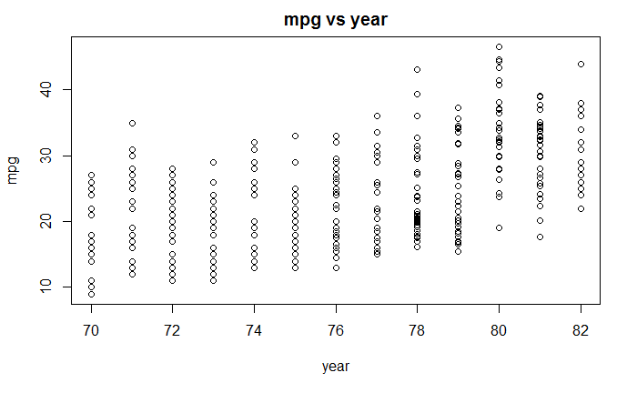

```r
plot(data$year, data$mpg, main = "mpg vs year", xlab = "year", ylab = "mpg")
```

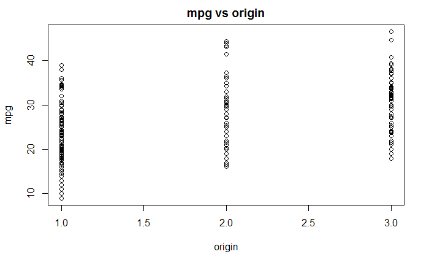

```r
plot(data$origin, data$mpg, main = "mpg vs origin", xlab = "origin", ylab = "mpg")
```

There is a negative relationship between mpg and cylinders, with the exception where number of cylinders equals 3. There is a negative relationship between mpg and displacement. There is a negative relationship between mpg and horsepower. There is a negative relationship between mpg and weight. There is not a clearly discernable relationship between mpg and acceleration. There seems to be a slightly positive relationship between mpg and year. There seems to be a slightly positive relationship between mpg and origin. Although, it is not displayed on a plot, it will also be interesting to explore the affect of manufacturer on mpg.

```r
# 6. Create a new attribute mpg1 that contains 1 if mpg is strictly greater than its median, and 0 if mpg is equal or less than its median.
data$mpg1 <- sapply(data$mpg, function(x) { if(x > median(data$mpg)) 1 else 0 })
```

```r
# 6a. Create a new attribute make that stores the car's manufacturer. Fix spelling errors. Store as factor.
data$make <- gsub("([A-Za-z]+).*", "\\1", data$name)
fixSpelling <- function(x) {
  if (x == "toyouta") { return ("toyota") }
  if (x == "maxda") { return ("mazda") }
  if (x == "chevroelt") { return ("chevrolet") }
  return (x)
}
data$make <- as.factor(sapply(data$make, fixSpelling))
```

```r
# 7. Decide which attributes you are going to use to predict mpg1. Remove all remaining attributes, including mpg.
data_with_categorical <- subset(data, select = c("mpg1", "weight", "displacement", "cylinders", "horsepower", "acceleration", "year", "make", "origin"))
data_only_numeric <- subset(data, select = c("mpg1", "weight", "displacement", "cylinders", "horsepower", "acceleration", "year"))
```

```r
# 7a. Dummy out categorical variables.
data_with_categorical$origin <- as.factor(data_with_categorical$origin)
data_dummy <- dummyVars(" ~ .", data = data_with_categorical)
data_with_categorical <- data.frame(predict(data_dummy, newdata = data_with_categorical))
```

In order to keep things simple to start and to establish a baseline model, I included only the numerical attributes - “mpg1”, “weight”, “displacement”, “cylinders”, “horsepower”, “acceleration”, and “year” - in my training set. I was also interested, however, to see how origin and manufacturer would affect the performance so I created a second training set for the numerical attributes plus these categorical attributes. In order to run knn with this second set, I had to (1) extract the manufacturer name (i.e., make) from the name attribute, (2) coerce make and origin to factors, and then create dummy attributes to indicate the presence or abensce of each feature for each observation.

```r
# 8. Set the seed of the random number generator to a fixed integer, say 1, so that you can reproduce your work.
set.seed(1)
```

```r
# 9. Normalize the attribute values.
normalize <- function(x) { return ((x - min(x)) / (max(x) - min(x))) }
data_with_categorical_normal <- as.data.frame(lapply(data_with_categorical, normalize))
data_only_numeric_normal<- as.data.frame(lapply(data_only_numeric, normalize))
```

```r
# 10. Randomize the order of the rows in the dataset.
data_with_categorical_random <- data_with_categorical_normal[sample(nrow(data_with_categorical_normal)), ]
data_only_numeric_random <- data_only_numeric_normal[sample(nrow(data_only_numeric_normal)), ]
```

```r
# 11. Split the data into a training set and a test set. Use a test set of 100 rows.
# With categorical
data_with_categorical_train <- data_with_categorical_random[1:(nrow(data_with_categorical_random)-100), ]
data_with_categorical_test <- data_with_categorical_random[(nrow(data_with_categorical_random)-99):nrow(data_with_categorical_random), ]
X_with_categorical_train <- data_with_categorical_train[,2:ncol(data_with_categorical_train)]
y_with_categorical_train <- data_with_categorical_train[,1]
X_with_categorical_test <- data_with_categorical_test[,2:ncol(data_with_categorical_test)]
y_with_categorical_test <- data_with_categorical_test[,1]
# Only numeric
data_only_numeric_train <- data_only_numeric_random[1:(nrow(data_only_numeric_random)-100), ]
data_only_numeric_test <- data_only_numeric_random[(nrow(data_only_numeric_random)-99):nrow(data_only_numeric_random), ]
X_only_numeric_train <- data_only_numeric_train[,2:ncol(data_only_numeric_train)]
y_only_numeric_train <- data_only_numeric_train[,1]
X_only_numeric_test <- data_only_numeric_test[,2:ncol(data_only_numeric_test)]
y_only_numeric_test <- data_only_numeric_test[,1]
```

```r
# 12. Perform kNN on the training data, with several values of K, in order to predict mpg1. What test errors do you obtain? Which value of K seems to perform the best on this dataset?
k_vals <- c(1, 5, 10, 15, 25, 30, 40, 60, 100)
# With categorical
evaluate_with_categorical_performance <- function(x) {
  y_with_categorical_pred <- knn(train = X_with_categorical_train, test = X_with_categorical_test, cl = y_with_categorical_train, k = x)
  y_with_categorical_CM <- confusionMatrix(data = y_with_categorical_pred, reference = y_with_categorical_test, mode = "prec_recall")
  y_with_categorical_accuracy <- y_with_categorical_CM$overall[['Accuracy']]
  y_with_categorical_recall <- y_with_categorical_CM$byClass[['Recall']]
  y_with_categorical_precision <- y_with_categorical_CM$byClass[['Precision']]
  y_with_categorical_false_negatives <- as.integer(y_with_categorical_CM$table[3])
  y_with_categorical_false_positives <- as.integer(y_with_categorical_CM$table[2])
  y_with_categorical_total_errors <- as.integer(y_with_categorical_false_negatives + y_with_categorical_false_positives)
  return (c(as.integer(x), y_with_categorical_accuracy, y_with_categorical_recall, y_with_categorical_precision, y_with_categorical_false_negatives, y_with_categorical_false_positives, y_with_categorical_total_errors))
}
knn_with_categorical_performance <- sapply(k_vals, evaluate_with_categorical_performance)
df_knn_with_categorical_performance <- as.data.frame(t(knn_with_categorical_performance))
colnames(df_knn_with_categorical_performance) <- c("k", "Accuracy", "Recall", "Precision", "False Neg", "False Pos", "Tot Errors")
attr(df_knn_with_categorical_performance, "title") <- "Performance of kNN on Dataset Including Categorical Attributes (Make, Origin)"
df_knn_with_categorical_performance
```

| k | Accuracy | Recall | Precision | False Neg | False Pos | Tot Errors |
| --- | --- | --- | --- | --- | --- | --- |
| 1 | 0.89 | 0.9166667 | 0.8627451 | 7 | 4 | 11 |
| 5 | 0.91 | 0.8750000 | 0.9333333 | 3 | 6 | 9 |
| 10 | 0.91 | 0.8958333 | 0.9148936 | 4 | 5 | 9 |
| 15 | 0.85 | 0.8958333 | 0.8113208 | 10 | 5 | 15 |
| 25 | 0.87 | 0.9375000 | 0.8181818 | 10 | 3 | 13 |
| 30 | 0.89 | 0.9375000 | 0.8490566 | 8 | 3 | 11 |
| 40 | 0.90 | 0.9375000 | 0.8653846 | 7 | 3 | 10 |
| 60 | 0.92 | 0.9375000 | 0.9000000 | 5 | 3 | 8 |
| 100 | 0.87 | 0.9166667 | 0.8301887 | 9 | 4 | 13 |

```r
# Only numeric
evaluate_only_numeric_performance <- function(x) {
  y_only_numeric_pred <- knn(train = X_only_numeric_train, test = X_only_numeric_test, cl = y_only_numeric_train, k = x)
  y_only_numeric_CM <- confusionMatrix(data = y_only_numeric_pred, reference = y_only_numeric_test, mode = "prec_recall")
  y_only_numeric_accuracy <- y_only_numeric_CM$overall[['Accuracy']]
  y_only_numeric_recall <- y_only_numeric_CM$byClass[['Recall']]
  y_only_numeric_precision <- y_only_numeric_CM$byClass[['Precision']]
  y_only_numeric_false_negatives <- as.integer(y_only_numeric_CM$table[3])
  y_only_numeric_false_positives <- as.integer(y_only_numeric_CM$table[2])
  y_only_numeric_total_errors <- as.integer(y_only_numeric_false_negatives + y_only_numeric_false_positives)
  return (c(as.integer(x), y_only_numeric_accuracy, y_only_numeric_recall, y_only_numeric_precision, y_only_numeric_false_negatives, y_only_numeric_false_positives, y_only_numeric_total_errors))
}
knn_only_numeric_performance <- sapply(k_vals, evaluate_only_numeric_performance)
df_knn_only_numeric_performance <- as.data.frame(t(knn_only_numeric_performance))
colnames(df_knn_only_numeric_performance) <- c("k", "Accuracy", "Recall", "Precision", "False Neg", "False Pos", "Tot Errors")
attr(df_knn_only_numeric_performance, "title") <- "Performance of kNN on Dataset Excluding Categorical Attributes"
df_knn_only_numeric_performance
```

| k | Accuracy | Recall | Precision | False Neg | False Pos | Tot Errors |
| --- | --- | --- | --- | --- | --- | --- |
| 1 | 0.98 | 0.9787234 | 0.9787234 | 1 | 1 | 2 |
| 5 | 0.98 | 0.9787234 | 0.9787234 | 1 | 1 | 2 |
| 10 | 0.93 | 0.9787234 | 0.8846154 | 6 | 1 | 7 |
| 15 | 0.96 | 0.9787234 | 0.9387755 | 3 | 1 | 4 |
| 25 | 0.95 | 0.9574468 | 0.9375000 | 3 | 2 | 5 |
| 30 | 0.95 | 0.9574468 | 0.9375000 | 3 | 2 | 5 |
| 40 | 0.95 | 0.9574468 | 0.9375000 | 3 | 2 | 5 |
| 60 | 0.96 | 0.9574468 | 0.9574468 | 2 | 2 | 4 |
| 100 | 0.97 | 0.9574468 | 0.9782609 | 1 | 2 | 3 |

```r
# Display Cross Table / Confusion Matrix for best performance
y_pred_best <- knn(train = X_only_numeric_train, test = X_only_numeric_test, cl = y_only_numeric_train, k = 5)
CrossTable(x = y_only_numeric_test, y = y_pred_best, prop.chisq = FALSE)
```

```
   Cell Contents
|-------------------------|
|                       N |
|           N / Row Total |
|           N / Col Total |
|         N / Table Total |
|-------------------------|


Total Observations in Table:  100


                    | y_pred_best
y_only_numeric_test |         0 |         1 | Row Total |
--------------------|-----------|-----------|-----------|
                  0 |        46 |         1 |        47 |
                    |     0.979 |     0.021 |     0.470 |
                    |     0.979 |     0.019 |           |
                    |     0.460 |     0.010 |           |
--------------------|-----------|-----------|-----------|
                  1 |         1 |        52 |        53 |
                    |     0.019 |     0.981 |     0.530 |
                    |     0.021 |     0.981 |           |
                    |     0.010 |     0.520 |           |
--------------------|-----------|-----------|-----------|
       Column Total |        47 |        53 |       100 |
                    |     0.470 |     0.530 |           |
--------------------|-----------|-----------|-----------|
```

```r
confusionMatrix(data = y_pred_best, reference = y_only_numeric_test, mode = "prec_recall")
```

```
Confusion Matrix and Statistics

          Reference
Prediction  0  1
         0 46  1
         1  1 52

               Accuracy : 0.98
                 95% CI : (0.9296, 0.9976)
    No Information Rate : 0.53
    P-Value [Acc > NIR] : <2e-16

                  Kappa : 0.9599
 Mcnemar's Test P-Value : 1

              Precision : 0.9787
                 Recall : 0.9787
                     F1 : 0.9787
             Prevalence : 0.4700
         Detection Rate : 0.4600
   Detection Prevalence : 0.4700
      Balanced Accuracy : 0.9799

       'Positive' Class : 0
```